# Двойной стек IPv4 и IPv6 в GNS3

Лабораторная работа №6

Суннатилло Махмудов

Российский университет дружбы народов, Москва, Россия

10 ноября 2025

# Цели и задачи работы

## Цель лабораторной работы

Изучение принципов настройки адресного пространства IPv4 и IPv6, построение сети с двойным стеком и проверка взаимодействия устройств в среде **GNS3**.

## Задачи

1. Выполнить разбиение IPv4 и IPv6 сетей на подсети.
2. Настроить адресацию на маршрутизаторах **FRR** и **VyOS**.
3. Проверить связность между узлами по протоколам **ICMP** и **ICMPv6**.
4. Проанализировать трафик с помощью **Wireshark**.
5. Подтвердить корректность работы протоколов **ARP**, **ICMP** и **ICMPv6**.

# Теоретическая часть

## Основные инструменты

- **GNS3** — эмулятор сетевой инфраструктуры.
- **FRRouting (FRR)** — платформа маршрутизации уровня L3.
- **VyOS** — дистрибутив Linux с функциями маршрутизатора.
- **VPCS** — эмулятор конечных узлов.
- **Wireshark** — анализатор сетевого трафика.

# Разбиение сетей

## IPv6: 2001:db8:c0de::/48

- Разделена на две подсети `/49` по идентификатору подсети.
- Вариант деления по Interface ID — два блока `/65`.

# Моделирование сети

## Топология

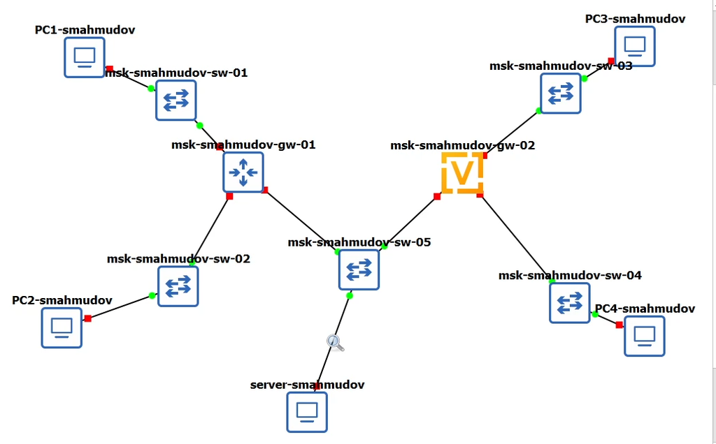

Топология сети

## Конфигурация узлов

[figure not shown]

Настройка IPv4

## FRR маршрутизатор

[figure not shown]

Настройка FRR

## Тестирование

[figure not shown]

Ping IPv4

## Конфигурация узлов

[figure not shown]

IPv6 конфигурация

## VyOS маршрутизатор

[figure not shown]

VyOS конфигурация

## Тестирование связности

[figure not shown]

ICMPv6

## Wireshark

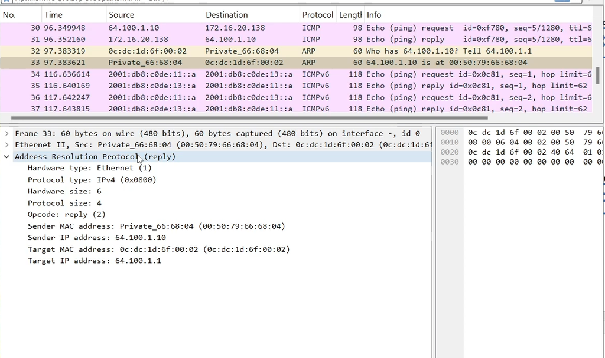

Анализ трафика

# Итоговая задача

## Две подсети и двойной стек

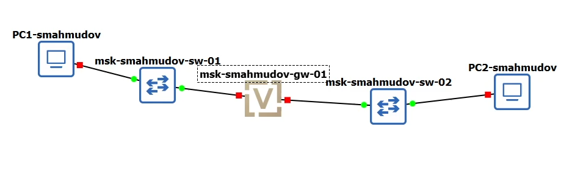

Топология двух подсетей

## Проверка

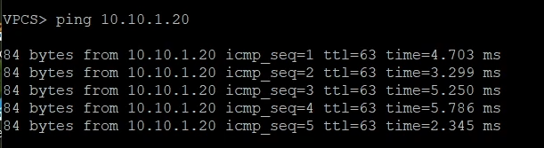

Проверка соединения